# Analysis of California groundwater stocks

Mia Guarnieri

11/18/2021

# 1 Overview

This memo assesses the resilience of California groundwater stocks in the face of increasing demand and declining recharge rate by analyzing the mass balance of total groundwater resources for California for the period of 2000 to 2050. The actual amount of groundwater within California is very difficult to measure, so to get a sense of water availability this report utilizes inflow and outflow data (groundwater recharge and discharge, respectively). Groundwater recharge occurs when water is added to groundwater sources via infiltration from rain or other surface water sources. Groundwater discharge refers to water exiting the reservoir, typically for human use such as irrigation and industry.

# 2 Data

This memo utilizes estimates of California water flows for both 2000 and 2050 provided by Elizabeth Curmi and colleagues in their article “Visualising a Stochastic Model of Californian Water Resources Using Sankey Diagrams”, published in Water Resources Management in 2013. Curmi and colleagues assessed cumulative groundwater use and future availability through two models: a baseline “business as usual” model, where no changes to water use are made, and a policy scenario in which there is a 20% reduction in average irrigated water use introduced in 2020 and a maximum water allowance of 31.6 × 10$^9$ m$^3$ for the agricultural sector. This memo will analyze predicted future groundwater availability following the “business as usual” model to examine what water resources will look like in California without further intervention.

*Assumptions*

For the 2050 estimates, the human population is estimated to increase to 55 million people, and the resulting increase in food demand is assumed to be met through imports. A policy to reduce urban per-capita water use by 2020 is also included as an assumption, due to California’s legislation in Chapter 4 of the Senate Bill No. 7. Finally, it is assumed that on average groundwater will continue to meet about 30% of California’s urban and agriculture water demand except in a dry year, when this percentage increases to more than 40%. Both models also adjust for differences in snowpack and timing of snowmelt due to climate change.

*Uncertainties*

The assumed parameters discussed above are uncertain, as future changes cannot be predicted with 100% accuracy. There is also uncertainty in the model about the proportion of total stored groundwater stocks that we will be extracting for use, due to uncertainty about future precipitation (recharge) and the total usable storage capacity of our groundwater sources. Uncertainty in future precipitation is considered explicitly in Curmi and colleagues’ analysis, and in the estimates provided in this memo (see section 3.2).

All analyses are in R version 4.1.1 using RStudio version 1.4.1717.

# 3 Analysis

## 3.1 Visualizing changes in groundwater inflow and outflow

Based on the data provided by Curmi and colleagues, inputs and outputs were calculated for California groundwater in 2000 and 2050. A linear model was then fitted to these values and plotted to visualize the change in groundwater inputs and outputs from 2000 to 2050.

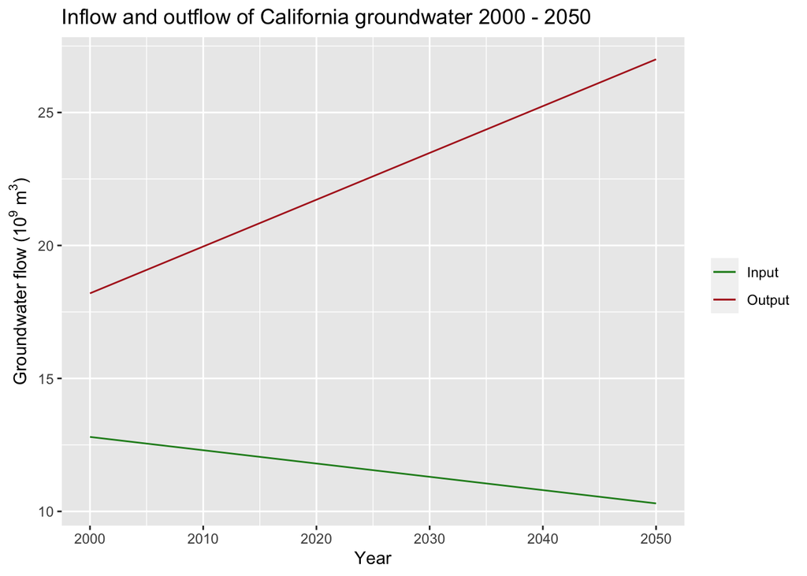

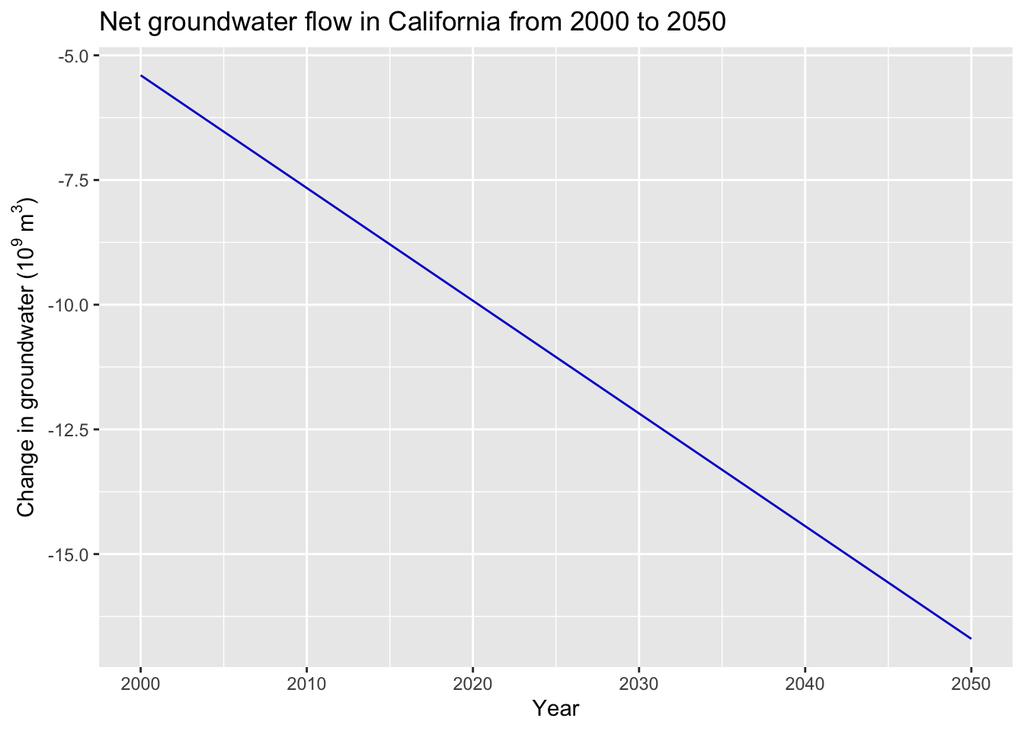

**Figure 2:** The predicted change in California groundwater flow (inflow of water - outflow of water) in 10$^9$ m$^3$ for the years 2000 to 2050. Net flow (y axis) is negative due to outflow being greater than inflow. Net flow of groundwater will decrease by 2.26 10$^9$ m$^3$ every ten years. Data: Curmi et al. 2013.

## 3.2 Visualizing changes in groundwater resources for three scenarios based on varying initial conditions of groundwater availability

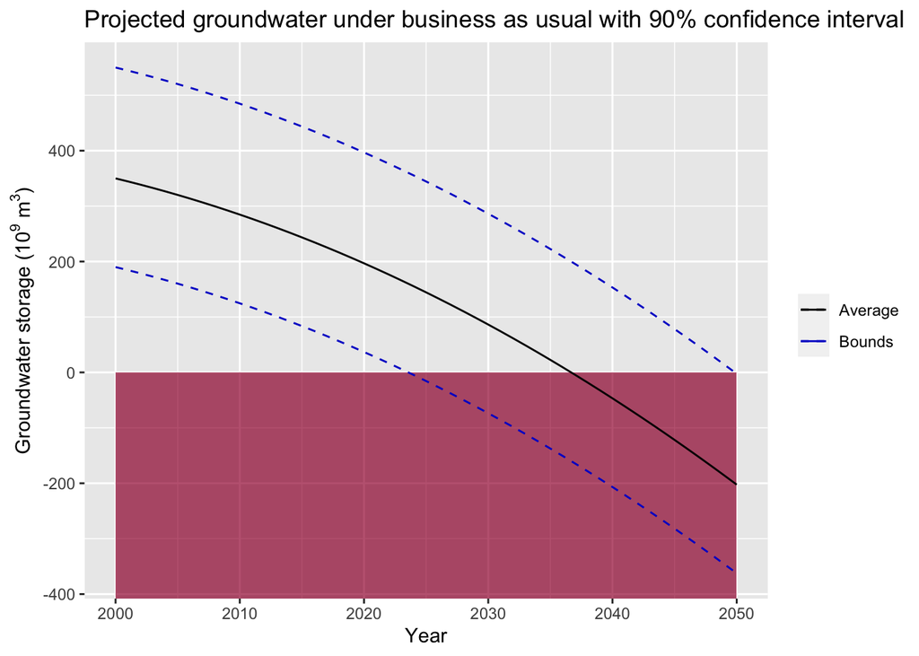

**Figure 3:** This graph shows change in groundwater storage (10$^9$ m$^3$) from 2000 to 2050 under three conditions for groundwater availability: low (lower dashed line, 190 x 10$^9$ m$^3$), expected (middle solid line, 350 x 10$^9$ m$^3$), and high (upper dashed line, 550 x 10$^9$ m$^3$). Groundwater storage at or below zero is shaded in red. Data: Curmi et al. 2013.

### 3.2.1 Takeaway

Based on the model predictions, if the initial expected estimate of groundwater availability is correct, we will reach zero groundwater storage between 2036 and 2037. If initial groundwater availability is high, we will reach zero groundwater storage in 2050. If initial groundwater availability is low, however we will reach zero groundwater storage much sooner, between 2023 and 2024. All three estimates show a decrease in groundwater storage as time goes on, indicating that if we do not reduce the outflow of water from our aquifers and other groundwater sources, we will likely functionally run out of groundwater by the year 2050 even under the best of circumstances.

# 4 Summary

Future analyses can incorporate additional adjustments in the predictive model, such as diverting water from non-essential uses like landscape irrigation to recharge groundwater sources (thus reducing discharge of groundwater while increasing recharge). Additional specific policy measures can also be incorporated into the model with different implementation dates, to assess their efficacy and determine appropriate timelines for implementation (near future, within the next decade, within the next 50 years, etc.).

# 5 Next steps

It is clear that action must be taken, preferably sooner rather than later, to reduce our usage of groundwater sources, increase the amount of water going toward replenishing these sources, or both. These initial investigations may appear grim, but there is still time to make crucial adjustments that can extend the longevity of these critical water sources so that they are available for future generations.

Some potential next steps we can take include:

- Assessing where our groundwater extraction can be reduced. Most extracted groundwater is used for agricultural purposes (Curmi et al. 2013), so that may be an area of water usage to further investigate first, but there are certainly other areas where we can reduce water usage such as landscape irrigation.
- Examining ways to increase groundwater recharge (refilling of aquifers and other groundwater sources). Most surface water either flows in rivers, is pumped to reservoirs and wetlands to maintain ecosystem services, or is delivered to farmers for irrigation (Curmi et al. 2013) but we may be able to redirect some of this water for groundwater recharge to preserve our groundwater sources.
- Precipitation in California is heavily seasonal; we can consider enforcing stricter water usage legislation during the summer months when surface water is scarce and we must rely on groundwater, and prioritize sequestering or storing surface water to replenish and reduce our reliance on groundwater sources during the winter months when it is more plentiful.

# 6 Citation

Curmi et al. (2013). Visualising a stochastic model of Californian water resources using Sankey diagrams. Water Resources Management, 27(8), 3035–3050.